# Prosper Loan Analysis

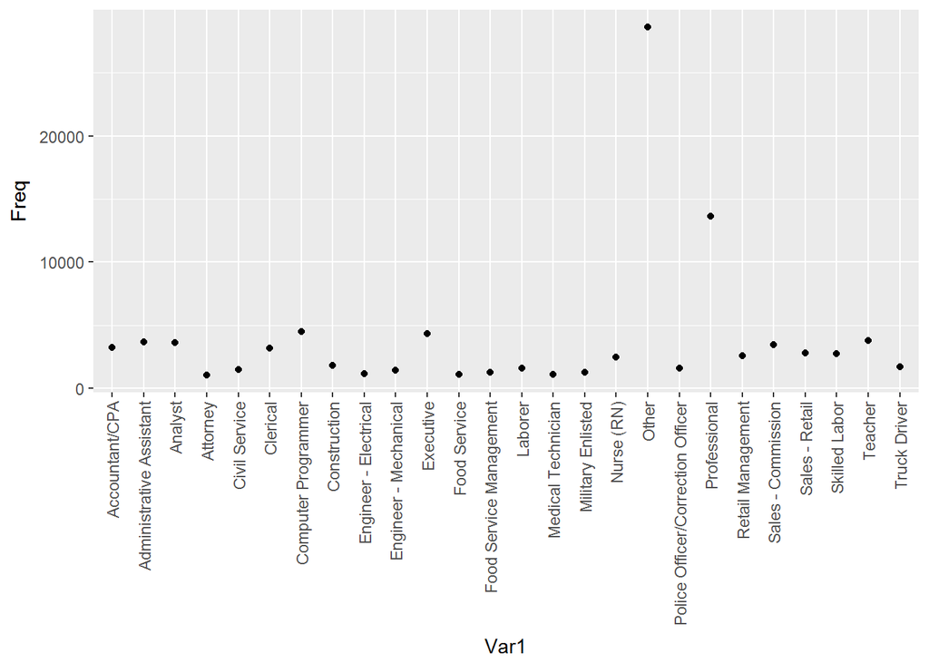

We see that 32% of our population has had at least 1 delinquincy in the last 7 years. This will be important as we explore further and try to answer our original question.

```
##  DelinquenciesLast7Years
##  Min.   : 0.000
##  1st Qu.: 0.000
##  Median : 0.000
##  Mean   : 4.155
##  3rd Qu.: 3.000
##  Max.   :99.000
##  NA's   :990
```

```
##           n
## 1 0.3204227
```

Another important thing to explore would be someone’s monthly income. Someone with a higher income should be better at being able to repay a loan. We will keep this question in mind, when doing deeper analysis further in the report. We would also like to know if the income was verified to forsee any potential problems. Less than 10% of the population dont have their income verified.

```
##  StatedMonthlyIncome
##  Min.   :      0
##  1st Qu.:   3200
##  Median :   4667
##  Mean   :   5608
##  3rd Qu.:   6825
##  Max.   :1750003
```

```
##  IncomeVerifiable
##  False:  8669
##  True :105268
```

```
## # A tibble: 1 x 1
##       n
##   <int>
## 1  8669
```

Only 2131 people had investments made by friends. We can explore if this had an affect on their repayment of the loan, later in the report

```
##   InvestmentFromFriendsCount
## 1                          0
## 2                          0
## 3                          0
## 4                          0
## 5                          0
## 6                          0
```

```
##  InvestmentFromFriendsCount
##  Min.   : 0.00000
##  1st Qu.: 0.00000
##  Median : 0.00000
##  Mean   : 0.02346
##  3rd Qu.: 0.00000
##  Max.   :33.00000
```

```
## # A tibble: 1 x 1
##       n
##   <int>
## 1  2131
```

Looking at the summary for borrower’s ProsperScore, we find a fairly normal distribution. There are also almost 30,000 borrowers that dont have a Prosper Score. This will be important to keep in mind.

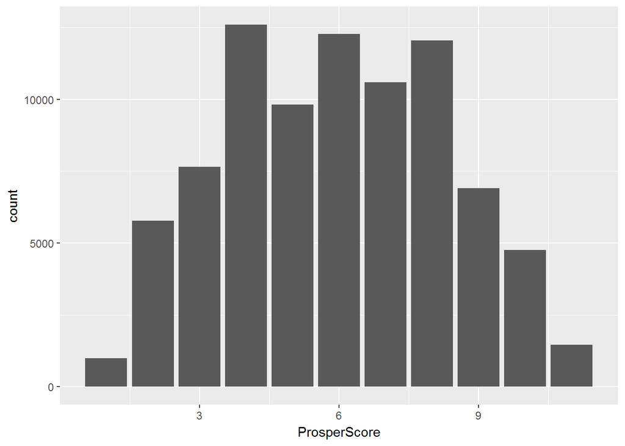

Another variable we can consider is Borrowers intrest rate. Would a higher Interest rate lead to more defualts? We can explore this question in the next section. We also have Borrrower Rate and Borrower APR. These two variables usually refer to the same thing. They also have similar values. We will try to investigate why they are being treated as two different variables.

```
##   BorrowerAPR
##  Min.   :0.00653
##  1st Qu.:0.15629
##  Median :0.20976
##  Mean   :0.21883
##  3rd Qu.:0.28381
##  Max.   :0.51229
##  NA's   :25
```

```
##   BorrowerRate
##  Min.   :0.0000
##  1st Qu.:0.1340
##  Median :0.1840
##  Mean   :0.1928
##  3rd Qu.:0.2500
##  Max.   :0.4975
```

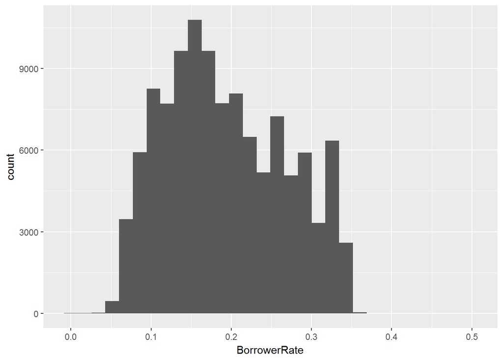

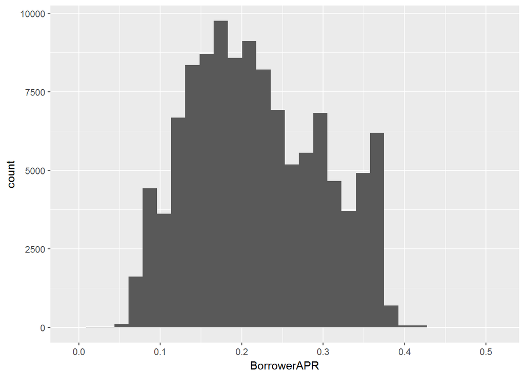

Another variable to consider could be IsHomeOwner. Being a homeowner could mean someone is responsible and therefore better able to pay back a loan. 57478 borrowers are homeowners.

```
## 'data.frame':    113937 obs. of  1 variable:
##  $ IsBorrowerHomeowner: Factor w/ 2 levels "False","True": 2 1 1 2 2 2 1 1 2 2 ...
```

```
##   IsBorrowerHomeowner
## 1                True
## 2               False
## 3               False
## 4                True
## 5                True
## 6                True
```

```
## # A tibble: 1 x 1
##       n
##   <int>
## 1 57478
```

```
##  ListingCategory..numeric.
##  Min.   : 0.000
##  1st Qu.: 1.000
##  Median : 1.000
##  Mean   : 2.774
##  3rd Qu.: 3.000
##  Max.   :20.000
```

```
##   ListingCategory..numeric.
## 1                         0
## 2                         2
## 3                         0
## 4                        16
## 5                         2
## 6                         1
```

```
## # A tibble: 1 x 1
##       n
##   <int>
## 1 96972
```

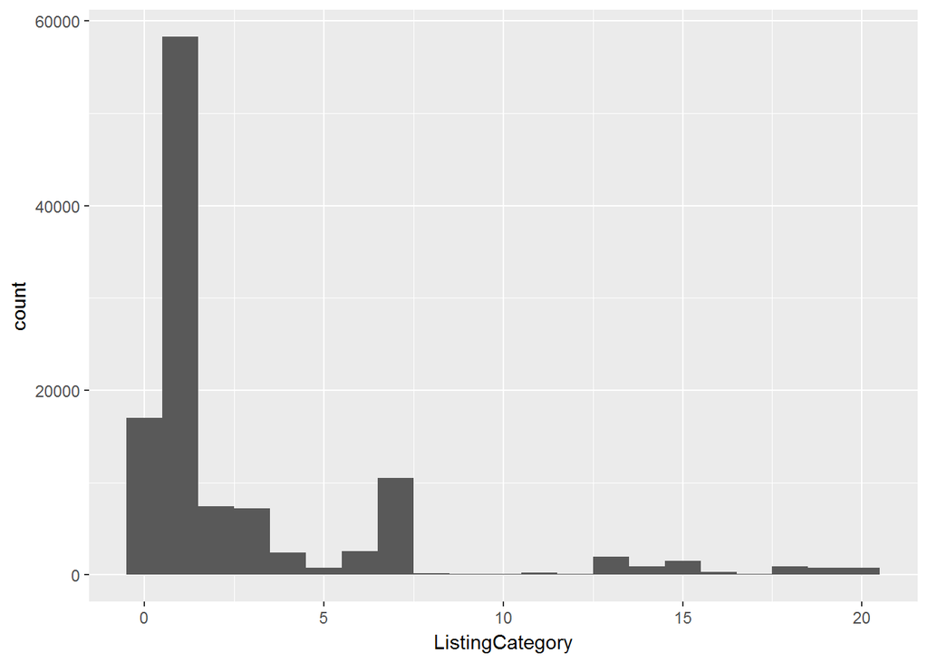

We can also look at recommendations and see if they have any effect on loan replayment. There are only 4259 borrowers who recieved a recommendation, so this might not be a viable path to go down.

```
##   Recommendations
## 1               0
## 2               0
## 3               0
## 4               0
## 5               0
## 6               0
```

```
##  Recommendations
##  Min.   : 0.00000
##  1st Qu.: 0.00000
##  Median : 0.00000
##  Mean   : 0.04803
##  3rd Qu.: 0.00000
##  Max.   :39.00000
```

```
## # A tibble: 1 x 1
##       n
##   <int>
## 1  4259
```

Another Interesting point of study could be Credit Grade, but considering there are 84984 missing values we may have to pass this up. The data is very uniform however, so it might be useful in later analysis.

```
##   CreditGrade
##  C      : 5649
##  D      : 5153
##  B      : 4389
##  AA     : 3509
##  HR     : 3508
##  (Other): 6745
##  NA's   :84984
```

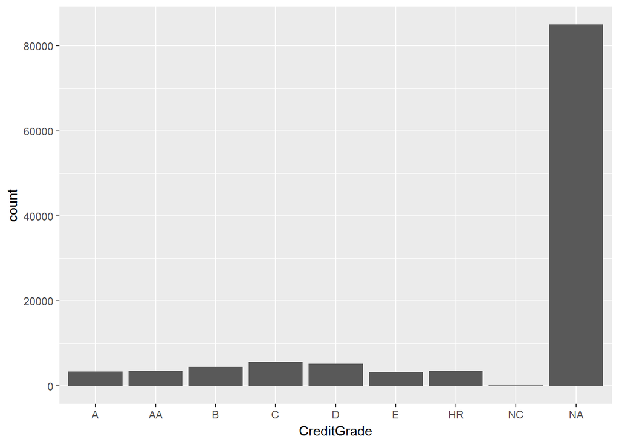

We will continue our investigation of the variables and see if we find anything interesting

Interesting point about this dataset is the average estimated loss on a loan is 8%.

```
##  EstimatedLoss
##  Min.   :0.005
##  1st Qu.:0.042
##  Median :0.072
##  Mean   :0.080
##  3rd Qu.:0.112
##  Max.   :0.366
##  NA's   :29084
```

```
##   EstimatedLoss
## 1            NA
## 2        0.0249
## 3            NA
## 4        0.0249
## 5        0.0925
## 6        0.0449
```

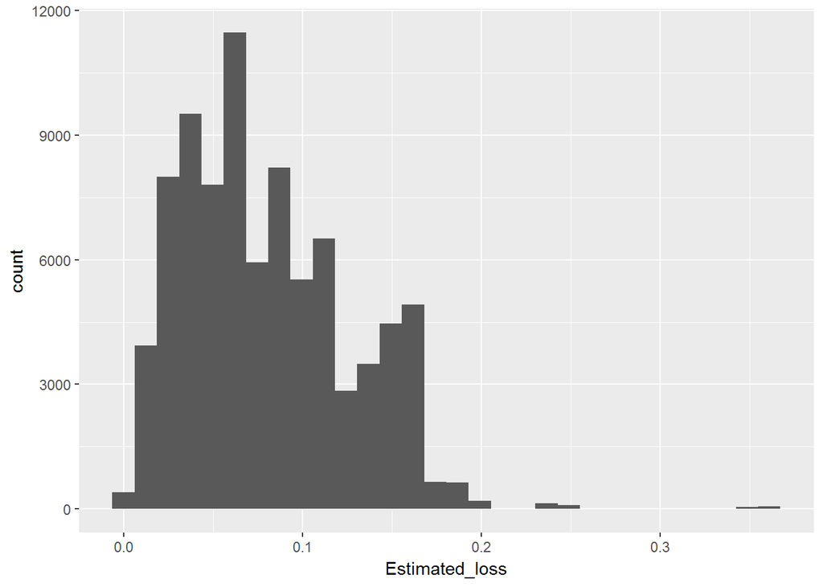

The average estimated return is 9%. Are they making an estimated average 1% profit on these loans?

```
##  EstimatedReturn
##  Min.   :-0.183
##  1st Qu.: 0.074
##  Median : 0.092
##  Mean   : 0.096
##  3rd Qu.: 0.117
##  Max.   : 0.284
##  NA's   :29084
```

```
##   EstimatedReturn
## 1              NA
## 2         0.05470
## 3              NA
## 4         0.06000
## 5         0.09066
## 6         0.07077
```

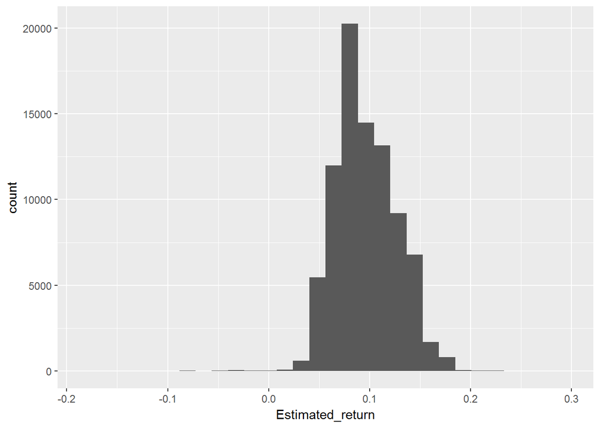

Im not that fimiliar with the finance world, but I was surprised to see the average number of credit lines was 10. This seems like a lot.

```
##  CurrentCreditLines
##  Min.   : 0.00
##  1st Qu.: 7.00
##  Median :10.00
##  Mean   :10.32
##  3rd Qu.:13.00
##  Max.   :59.00
##  NA's   :7604
```

```
##   CurrentCreditLines
## 1                  5
## 2                 14
## 3                 NA
## 4                  5
## 5                 19
## 6                 21
```

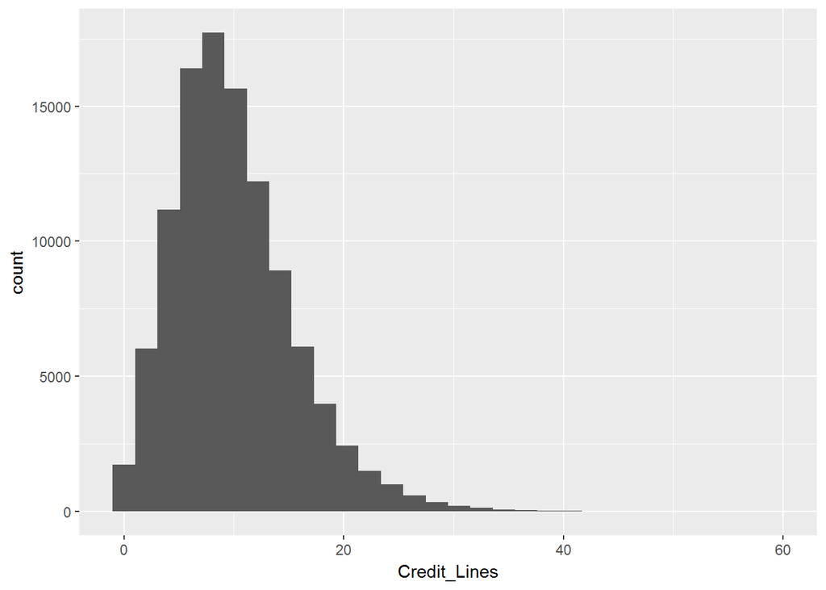

Average open Credit Lines are 9.26. This is consistant with the last variable.

```
##  OpenCreditLines
##  Min.   : 0.00
##  1st Qu.: 6.00
##  Median : 9.00
##  Mean   : 9.26
##  3rd Qu.:12.00
##  Max.   :54.00
##  NA's   :7604
```

```
##   OpenCreditLines
## 1               4
## 2              14
## 3              NA
## 4               5
## 5              19
## 6              17
```

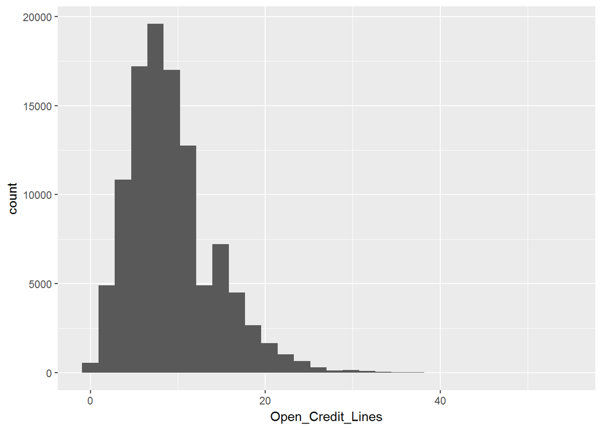

Almost 27 credit lines opened in last 7 years on average. WOW.

```
##  TotalCreditLinespast7years
##  Min.   :  2.00
##  1st Qu.: 17.00
##  Median : 25.00
##  Mean   : 26.75
##  3rd Qu.: 35.00
##  Max.   :136.00
##  NA's   :697
```

```
##   TotalCreditLinespast7years
## 1                         12
## 2                         29
## 3                          3
## 4                         29
## 5                         49
## 6                         49
```

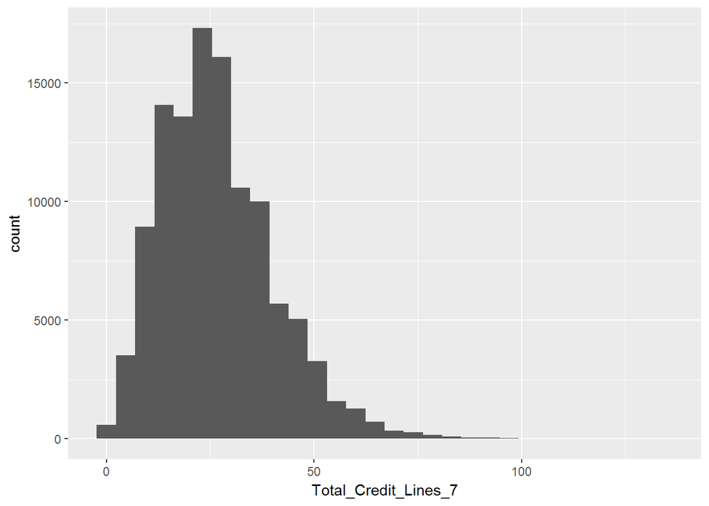

THis is similar to credit lines. Nothing noteworthy.

```
##  OpenRevolvingAccounts
##  Min.   : 0.00
##  1st Qu.: 4.00
##  Median : 6.00
##  Mean   : 6.97
##  3rd Qu.: 9.00
##  Max.   :51.00
```

```
##   OpenRevolvingAccounts
## 1                     1
## 2                    13
## 3                     0
## 4                     7
## 5                     6
## 6                    13
```

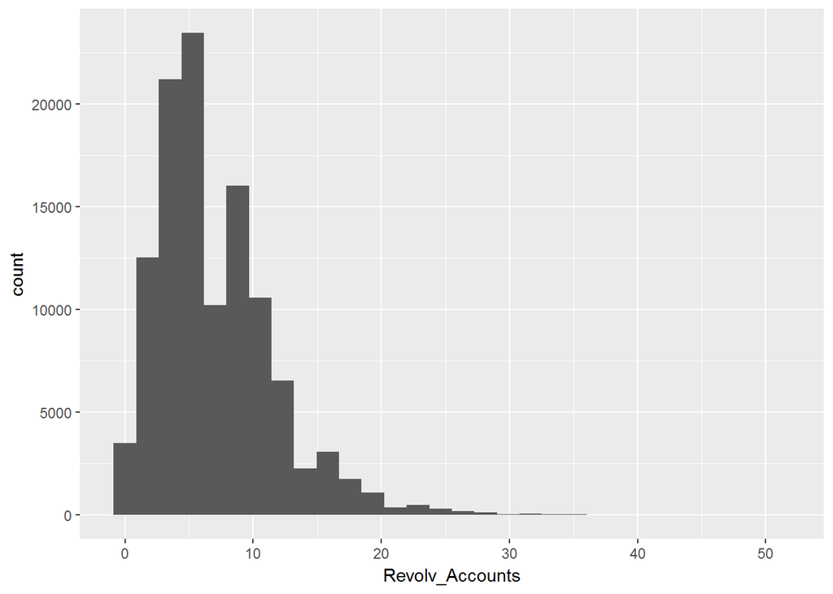

$271 median monthly payment. This is a big monthly expense.

```
##  OpenRevolvingMonthlyPayment
##  Min.   :    0.0
##  1st Qu.:  114.0
##  Median :  271.0
##  Mean   :  398.3
##  3rd Qu.:  525.0
##  Max.   :14985.0
```

```
##   OpenRevolvingMonthlyPayment
## 1                          24
## 2                         389
## 3                           0
## 4                         115
## 5                         220
## 6                        1410
```

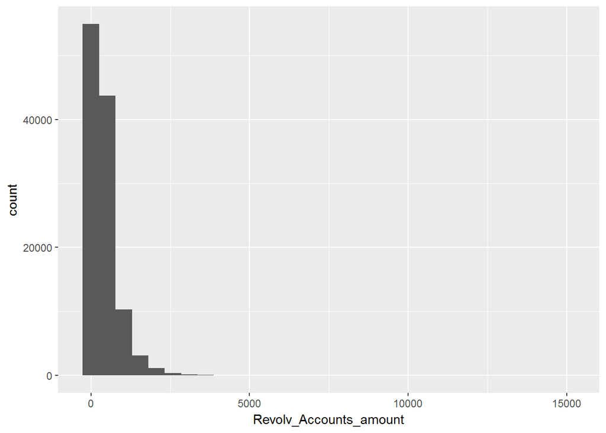

24000 people currently have a delinquincy. This variable will be important in later analysis.

```
##  CurrentDelinquencies
##  Min.   : 0.0000
##  1st Qu.: 0.0000
##  Median : 0.0000
##  Mean   : 0.5921
##  3rd Qu.: 0.0000
##  Max.   :83.0000
##  NA's   :697
```

```
##   CurrentDelinquencies
## 1                    2
## 2                    0
## 3                    1
## 4                    4
## 5                    0
## 6                    0
```

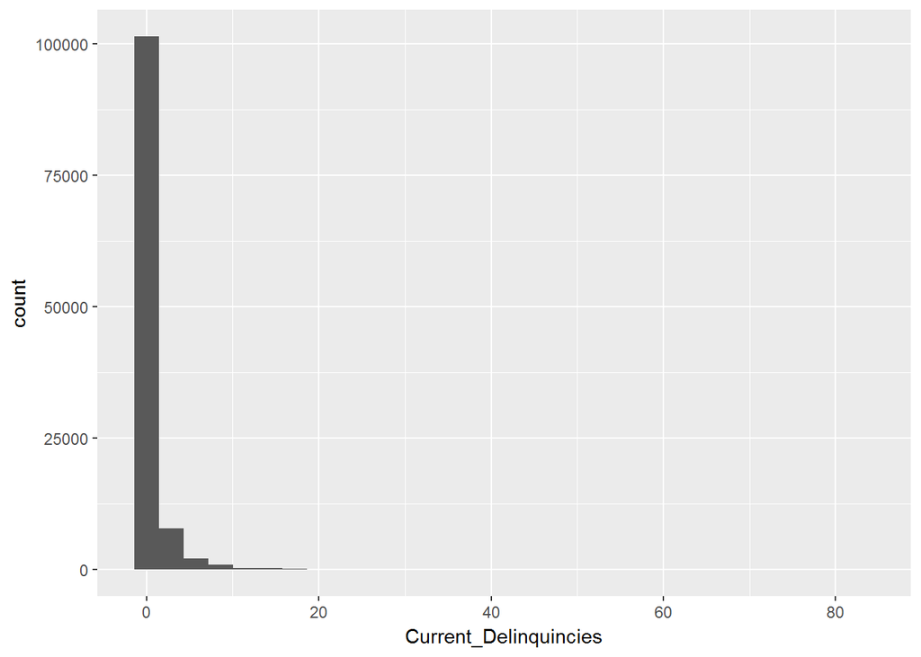

```
## # A tibble: 1 x 1
##       n
##   <int>
## 1 23498
```

Nothing jumps out immediately, excpet for the poor guy who has monthly expenses that is 10 times his monthly income. We will explore this variable further in the report.

```
##  DebtToIncomeRatio
##  Min.   : 0.000
##  1st Qu.: 0.140
##  Median : 0.220
##  Mean   : 0.276
##  3rd Qu.: 0.320
##  Max.   :10.010
##  NA's   :8554
```

```
##   DebtToIncomeRatio
## 1              0.17
## 2              0.18
## 3              0.06
## 4              0.15
## 5              0.26
## 6              0.36
```

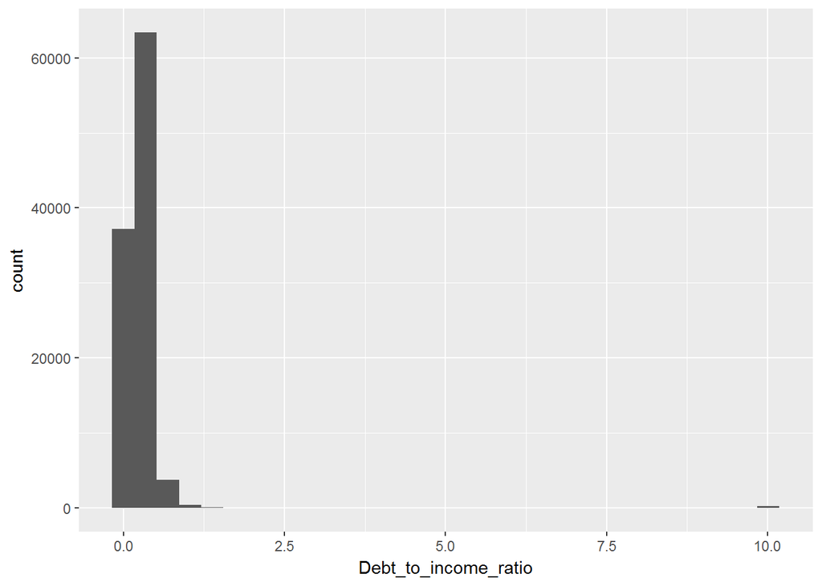